## Challenge:

Parte 1: Preguntas de 1 a 4 en Python:

# 0.- Librerias y directorio

```python
import os
import pandas as pd
import numpy as np
import matplotlib.pyplot as plt
import seaborn as sns
import scipy.stats as stats
import missingno as msngo
import datetime
import warnings
warnings.filterwarnings("ignore")
```

```python
ruta = "C:\\Users\\Felipe\\Spike"
```

```python
os.chdir(ruta)
```

```python
os.getcwd()
```

```
'C:\\Users\\Felipe\\Spike'
```

# 1.- Datos

```python
banco = pd.read_csv("https://github.com/SpikeLab-CL/desafio_spike_precios/raw/main/banco_central.csv")
precip = pd.read_csv("https://github.com/SpikeLab-CL/desafio_spike_precios/raw/main/precipitaciones.csv")
leche = pd.read_csv("https://github.com/SpikeLab-CL/desafio_spike_precios/raw/main/precio_leche.csv")
```

# 2.- EDA

```python
banco.head(1)
```

|  | Periodo | Imacec_empalmado | Imacec_produccion_de_bienes | Imacec_minero | Imacec_industria | Imacec_resto_de_bienes | Imacec_comercio | Imacec_servicios | Imacec_a_costo_de_factores | Imacec_no_minero | ... | Indice_de_tipo_de_cambio_real___TCR_promedio_1986_100 | Indice_de_produccion_industrial | Indice_de_produccion_industrial__mineria | Indice_de_produccion_industrial_electricidad__gas_y_agua | Indice_de_produccion_industrial__manufacturera | Generacion_de_energia_electrica_CDEC_GWh | Indice_de_ventas_comercio_real_IVCM | Indice_de_ventas_comercio_real_no_durables_IVCM | Indice_de_ventas_comercio_real_durables_IVCM | Ventas_autos_nuevos |
| --- | --- | --- | --- | --- | --- | --- | --- | --- | --- | --- | --- | --- | --- | --- | --- | --- | --- | --- | --- | --- | --- |
| 0 | 2013-03-01 00:00:00 UTC | 102.796.218 | 10.546.824 | 978.554.365 | 102.297.537 | 114.994.919 | 110.729.395 | 100.064.328 | 103.163.651 | 103.405.852 | ... | 865.903.468 | 102.761.705 | 98.915.705 | NaN | 108.387.837 | 580.480.672 | NaN | NaN | NaN | 28577.0 |

1 rows × 85 columns

```python
precip.head(1)
```

|  | date | Coquimbo | Valparaiso | Metropolitana_de_Santiago | Libertador_Gral__Bernardo_O_Higgins | Maule | Biobio | La_Araucania | Los_Rios |
| --- | --- | --- | --- | --- | --- | --- | --- | --- | --- |
| 0 | 1989-02-01 | 0.719033 | 0.117045 | 0.028272 | 0.0 | 0.724667 | 9.172945 | 22.595834 | 52.26801 |

```python
precip.shape
```

```
(496, 9)
```

```python
leche.head(1)
```

|  | Anio | Mes | Precio_leche |
| --- | --- | --- | --- |
| 0 | 1979 | Ene | 3.85 |

```python
leche.shape
```

```
(506, 3)
```

Parece no existir problema con los datos importados

A continuación se realizarán análisis sobre las variables, primero para banco central, luego para el set de precipitaciones y finalmente para la variable respuesta leche:

## Banco

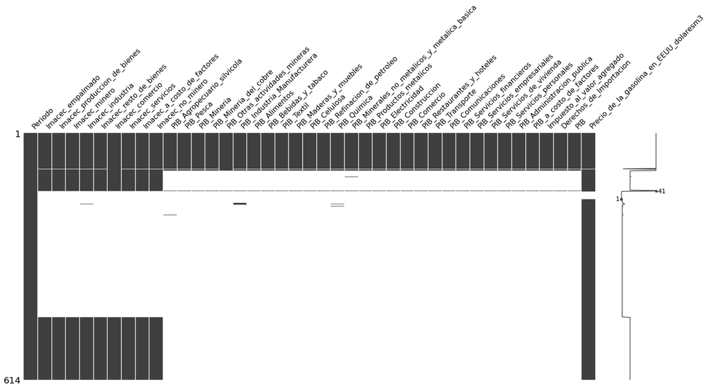

```python
msngo.matrix(banco.iloc[:, : 41]);
```

Siguientes 45

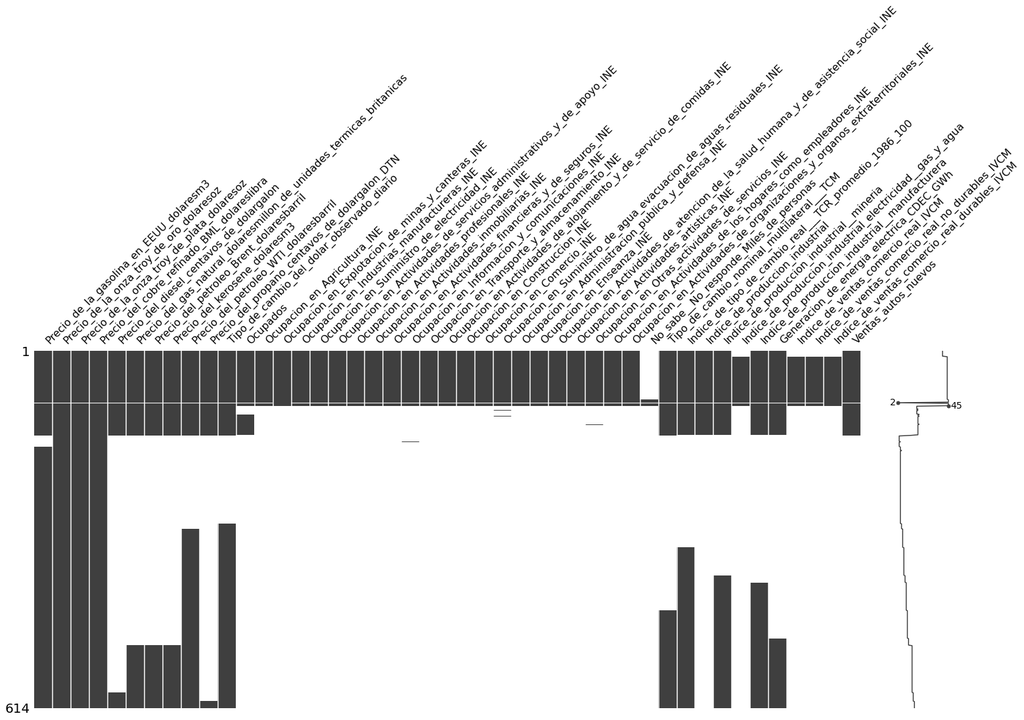

```python
msngo.matrix(banco.iloc[:, 40: 85]);
```

Rapidamente se observa una gran cantidad de data perdida con la excepción de 5 campos:

- Periodo
- Precio_de_la_gasolina_en_EEUU_dolaresm3
- Precio_de_la_onza_troy_de_oro_dolaresoz
- Precio_de_la_onza_troy_de_plata_dolaresoz
- Precio_del_cobre_refinado_BML_dolareslibra

Evidentemente una elimiación de todos los registros no nulos es lo menos óptimo que se puede hacer. Se pueden crear datos artificiales para rellenar unos datos en función de otros con algoritmos como el EM. Sin embargo no tiene sentido crear variables auxiliares entre ellas mismas, pues generaría una alta correlación, lo cual puede desencadenar en colinealidad del modelo, que por ser series de tiempo con regresores, es probable que se opte por un SARIMAX

```python
banco.info()
```

```
<class 'pandas.core.frame.DataFrame'>
RangeIndex: 614 entries, 0 to 613
Data columns (total 85 columns):
 #   Column                                                                              Non-Null Count  Dtype
---  ------                                                                              --------------  -----
 0   Periodo                                                                             614 non-null    object
 1   Imacec_empalmado                                                                    300 non-null    object
 2   Imacec_produccion_de_bienes                                                         300 non-null    object
 3   Imacec_minero                                                                       300 non-null    object
 4   Imacec_industria                                                                    301 non-null    object
 5   Imacec_resto_de_bienes                                                              300 non-null    object
 6   Imacec_comercio                                                                     301 non-null    object
 7   Imacec_servicios                                                                    300 non-null    object
 8   Imacec_a_costo_de_factores                                                          300 non-null    object
 9   Imacec_no_minero                                                                    300 non-null    object
```

[output cut: 77 more lines]

En concordancia con lo anterior, de los 614 registros que tiene el set de datos, la gran mayoria solo posee información de 95 registros.

Notar que la fecha tiene fechas erroneas, como mes 13, siendo que el formato es yyyy-mm-dd, no yyyy-dd-mm. Además todas las horas son 00:00:00, por lo que se removerán y se hará un join por fecha

```python
banco[banco['Periodo'].str.slice(0,10)=='2020-13-01']
```

|  | Periodo | Imacec_empalmado | Imacec_produccion_de_bienes | Imacec_minero | Imacec_industria | Imacec_resto_de_bienes | Imacec_comercio | Imacec_servicios | Imacec_a_costo_de_factores | Imacec_no_minero | ... | Indice_de_tipo_de_cambio_real___TCR_promedio_1986_100 | Indice_de_produccion_industrial | Indice_de_produccion_industrial__mineria | Indice_de_produccion_industrial_electricidad__gas_y_agua | Indice_de_produccion_industrial__manufacturera | Generacion_de_energia_electrica_CDEC_GWh | Indice_de_ventas_comercio_real_IVCM | Indice_de_ventas_comercio_real_no_durables_IVCM | Indice_de_ventas_comercio_real_durables_IVCM | Ventas_autos_nuevos |
| --- | --- | --- | --- | --- | --- | --- | --- | --- | --- | --- | --- | --- | --- | --- | --- | --- | --- | --- | --- | --- | --- |
| 89 | 2020-13-01 00:00:00 UTC | NaN | NaN | NaN | NaN | NaN | 803.222.345 | NaN | NaN | NaN | ... | NaN | NaN | NaN | NaN | NaN | NaN | NaN | NaN | 893.234.345 | NaN |

1 rows × 85 columns

Se elimina dicho registro pues no aporta información, y se transforma la fecha

```python
banco = banco.drop(banco.index[89])
```

```python
banco['Periodo'] = pd.to_datetime(banco['Periodo'].str.slice(0,10), format = '%Y-%m-%d')
```

```python
banco['Periodo'].describe()
```

```
count                     613
unique                    611
top       2019-08-01 00:00:00
freq                        2
first     1970-01-01 00:00:00
last      2020-11-01 00:00:00
Name: Periodo, dtype: object
```

Analicemos los campos con al menos 70% de información (a lo más 30% de casos perdidos)

```python
BancoNoNas = banco[banco.columns[banco.isna().mean()<0.30 ]]
```

Se modifica al formato de campo correcto

```python
BancoNoNas.info()
```

```
<class 'pandas.core.frame.DataFrame'>
Int64Index: 613 entries, 0 to 613
Data columns (total 7 columns):
 #   Column                                      Non-Null Count  Dtype
---  ------                                      --------------  -----
 0   Periodo                                     613 non-null    datetime64[ns]
 1   Precio_de_la_gasolina_en_EEUU_dolaresm3     594 non-null    object
 2   Precio_de_la_onza_troy_de_oro_dolaresoz     613 non-null    float64
 3   Precio_de_la_onza_troy_de_plata_dolaresoz   613 non-null    float64
 4   Precio_del_cobre_refinado_BML_dolareslibra  613 non-null    object
 5   Precio_del_petroleo_WTI_dolaresbarril       453 non-null    float64
 6   Tipo_de_cambio_del_dolar_observado_diario   462 non-null    object
dtypes: datetime64[ns](1), float64(3), object(3)
memory usage: 38.3+ KB
```

```python
BancoNoNas.sort_values(by='Periodo', ascending=False)
```

|  | Periodo | Precio_de_la_gasolina_en_EEUU_dolaresm3 | Precio_de_la_onza_troy_de_oro_dolaresoz | Precio_de_la_onza_troy_de_plata_dolaresoz | Precio_del_cobre_refinado_BML_dolareslibra | Precio_del_petroleo_WTI_dolaresbarril | Tipo_de_cambio_del_dolar_observado_diario |
| --- | --- | --- | --- | --- | --- | --- | --- |
| 145 | 2020-11-01 | 29.756.846 | 1866.35 | 240.693 | 320.395.083 | 41.10 | 762.884.762 |
| 94 | 2020-10-01 | 30.028.972 | 1900.36 | 241.857 | 304.035.653 | 39.53 | 788.267.143 |
| 93 | 2020-09-01 | 30.850.634 | 1923.35 | 257.916 | 30.447.292 | 39.60 | 773.402.381 |
| 92 | 2020-08-01 | 3.180.968 | 1969.78 | 270.033 | 294.688.379 | 42.36 | 784.661.905 |
| 91 | 2020-07-01 | 30.523.026 | 1846.37 | 205.899 | 288.204.663 | 40.75 | 784.729.091 |
| ... | ... | ... | ... | ... | ... | ... | ... |
| 150 | 1970-05-01 | NaN | 35.95 | 1.670 | 725 | NaN | NaN |
| 149 | 1970-04-01 | NaN | 35.62 | 1.850 | 0.79 | NaN | NaN |
| 148 | 1970-03-01 | NaN | 35.09 | 1.890 | 796 | NaN | NaN |
| 147 | 1970-02-01 | NaN | 34.99 | 1.900 | 752 | NaN | NaN |
| 146 | 1970-01-01 | NaN | 34.94 | 1.880 | 738 | NaN | NaN |

613 rows × 7 columns

Notar que el separador decimal y el separador de miles, en ambos casos usan un punto. Por ejemplo la columna precio de onza tiene 2 valores luego del punto, lo que tiene sentido pues son los centavos del precio. En este caso el punto es un separador decimal.

Pero por otro lado, columnas como "Precio_del_cobre_refinado_BML_dolareslibra" tienen dos separadores de puntos, lo cual no puede ser separador decimal.

Una rápida busqueda por google muestra que el Precio_del_cobre_refinado_BML_dolareslibra del 2020-11-01 es de 3.20 y en el set aparece el valor de 320.395.083. Además el set de datos al día 2020-09-01 tiene 30.447.292 y su valor real debiese ser 3.04. Esto evidencia un error en el largo del campo

Fuente: https://si3.bcentral.cl/siete/ES/Siete/Canasta?idCanasta=FHLES3325

Lo mismo se puede observar de otras columnas, por ejemplo el dolar, en la fecha más reciente aparece con un valor de '762.884.762' donde en dicha fecha fue de 762 pesos. Es por esto que la información de este set de datos parece estar alterada.

Dado lo anterior si yo estuviese trabajando en Spike, re-construiría el set de datos, pues la información del banco central es fácil de obtener (es información pública), y estimadores como PIB, precio del dolar, etc. son de fácil acceso.

Además como lo que se necesita hacer es una proyección del valor de la leche, un simple ARMA podría ya predecir mejor una proyección de precio que un SARIMAX con basura.

Sin embargo, solo por honor al tiempo, trabajaré con el set de datos tal y como está, pasando los string a números para hacer uso de su tendencia y estacionalidad, ignorando su escala

## Precipitaciones

```python
precip.info()
```

```
<class 'pandas.core.frame.DataFrame'>
RangeIndex: 496 entries, 0 to 495
Data columns (total 9 columns):
 #   Column                               Non-Null Count  Dtype
---  ------                               --------------  -----
 0   date                                 496 non-null    object
 1   Coquimbo                             496 non-null    float64
 2   Valparaiso                           496 non-null    float64
 3   Metropolitana_de_Santiago            496 non-null    float64
 4   Libertador_Gral__Bernardo_O_Higgins  496 non-null    float64
 5   Maule                                496 non-null    float64
 6   Biobio                               496 non-null    float64
 7   La_Araucania                         496 non-null    float64
 8   Los_Rios                             496 non-null    float64
dtypes: float64(8), object(1)
memory usage: 35.0+ KB
```

```python
precip = precip.sort_values(by=['date']).reset_index().drop('index',axis=1)
precip['date']=pd.to_datetime(precip['date'], format = '%Y-%m')
```

```python
precip['date']=pd.to_datetime(precip['date'], format = '%Y-%m-%d')
```

Este set de datos no presenta data perdida y los campos son numericos, solo fecha hay que transformarlo

```python
precip.describe()
```

|  | Coquimbo | Valparaiso | Metropolitana_de_Santiago | Libertador_Gral__Bernardo_O_Higgins | Maule | Biobio | La_Araucania | Los_Rios |
| --- | --- | --- | --- | --- | --- | --- | --- | --- |
| count | 496.000000 | 496.000000 | 496.000000 | 496.000000 | 496.000000 | 496.000000 | 496.000000 | 496.000000 |
| mean | 16.154691 | 32.450980 | 49.666682 | 72.249805 | 98.662773 | 128.113406 | 151.486456 | 199.451789 |
| std | 32.629286 | 55.434330 | 74.361099 | 101.426112 | 122.766771 | 130.056094 | 126.628503 | 140.073615 |
| min | 0.000000 | 0.000000 | 0.000000 | 0.000000 | 0.000000 | 0.001170 | 0.005331 | 0.748127 |
| 25% | 0.821521 | 1.538162 | 5.297546 | 5.343992 | 11.897363 | 29.356684 | 52.930343 | 89.805643 |
| 50% | 4.071036 | 9.037825 | 19.087592 | 25.995969 | 45.649888 | 79.558557 | 110.570990 | 159.467940 |
| 75% | 16.137600 | 38.409213 | 63.408364 | 101.875093 | 142.230716 | 184.751307 | 208.316243 | 274.594590 |
| max | 347.133889 | 441.048604 | 524.592667 | 645.515752 | 759.177712 | 702.434707 | 661.211203 | 717.735673 |

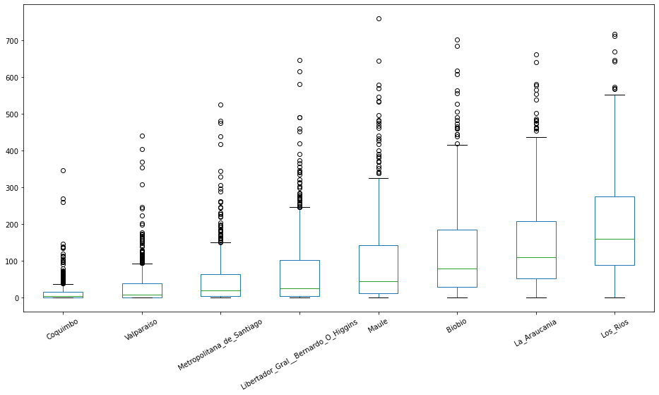

```python
plt.rcParams["figure.figsize"] = (16, 8)
precip.plot(kind='box',rot=30)
plt.show()
```

Sin entrar en visualización avanzada, se observa lo esperable: A medida que se avanza hacia el sur las precipitaciones son mayores. Los boxplot evidencian la falta de normalidad en todas las regiones (mediana lejos de la media).

Este set de datos si parece tener mayor utilidad

```python
precip[precip.duplicated(['date'])]
```

|  | date | Coquimbo | Valparaiso | Metropolitana_de_Santiago | Libertador_Gral__Bernardo_O_Higgins | Maule | Biobio | La_Araucania | Los_Rios |
| --- | --- | --- | --- | --- | --- | --- | --- | --- | --- |

No hay fechas duplicadas lo cual facilitará el tratamiento de serie temporal

## Leche

```python
leche.info()
```

```
<class 'pandas.core.frame.DataFrame'>
RangeIndex: 506 entries, 0 to 505
Data columns (total 3 columns):
 #   Column        Non-Null Count  Dtype
---  ------        --------------  -----
 0   Anio          506 non-null    int64
 1   Mes           506 non-null    object
 2   Precio_leche  506 non-null    float64
dtypes: float64(1), int64(1), object(1)
memory usage: 12.0+ KB
```

```python
leche.head()
```

|  | Anio | Mes | Precio_leche |
| --- | --- | --- | --- |
| 0 | 1979 | Ene | 3.85 |
| 1 | 1979 | Feb | 4.58 |
| 2 | 1979 | Mar | 5.18 |
| 3 | 1979 | Abr | 6.06 |
| 4 | 1979 | May | 7.25 |

Notar que no tenemos el día del vector respuesta por lo que formaremos columna fecha como yyyy-mm, con días igual a 1 siempre, para hacer un futuro match con los otros sets. Luego habrá que volver a hacer lo mismo en precip para homogeneizar ambos set y más adelante poder unirlos, además el formato de fecha viene como %b. Por temas de lenguaje se me hace más rápido pasarlo a numero con replace que cambiar características con locale del idioma

```python
leche=leche.replace(['Ene','Feb','Mar','Abr','May','Jun','Jul','Ago','Sep','Oct','Nov','Dic'],
              ['1','2','3','4','5','6','7','8','9','10','11','12'])
leche['fecha']= leche['Anio'].astype(str) +'-' +leche['Mes'] + '-01'
leche['fecha']=pd.to_datetime(leche['fecha'], format = '%Y-%m')
leche = leche.drop(['Anio','Mes'],axis=1)
```

```python
leche.head(2)
```

|  | Precio_leche | fecha |
| --- | --- | --- |
| 0 | 3.85 | 1979-01-01 |
| 1 | 4.58 | 1979-02-01 |

```python
leche[leche.duplicated(['fecha'])]
```

|  | Precio_leche | fecha |
| --- | --- | --- |

No tiene fechas duplicadas por lo que no debería haber problema en la serie temporal

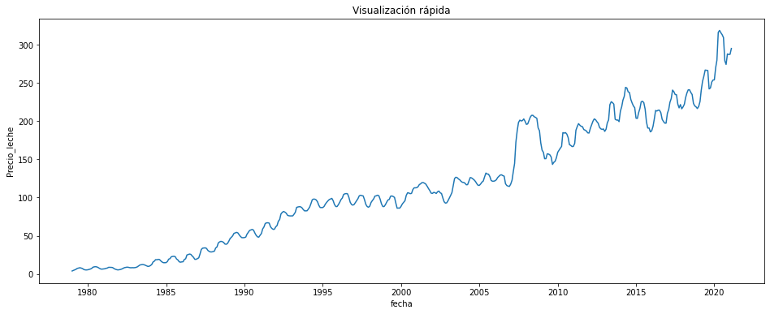

```python
fig, ax = plt.subplots(figsize = (16, 6))
sns.lineplot(ax = ax, x='fecha', y='Precio_leche', data=leche, markers=True);
plt.title('Visualización rápida');
```

Parece no existir problema con el vector de datos objetivos, muestra una clara tendencia al alza con el tiempo (esperable por inflación), no parece tener una fuerte irregularidad salvo el año de crisis financiera (2008) y su seasonality aparentemente es anual. (Se profundizará en esto más adelante)

# 3.- Visualización

```python
#banco['Tipo_de_cambio_del_dolar_observado_diario']=banco['Tipo_de_cambio_del_dolar_observado_diario'].str.replace('.','').astype(float)
```

```python
def grafprec(df = precip, region="Metropolitana_de_Santiago",fechamin='1999-01-01',fechamax= '2020-04-01'):
    '''
    Esta funcion recibe el DF, region (columna dentro del df) y rango de fechas (se asume que el df tiene fechas)
    Tiene corrección de errores para fechas o regiones mal ingresadas
    '''

    if (precip.columns.str.contains(region).any()):
        if (precip['date'].astype(str).str.contains(fechamin).any())&(precip['date'].astype(str).str.contains(fechamax).any()):
            dfaux= df[(df['date'] >= fechamin) & (df['date'] <=fechamax)]
            sns.set_theme(style="darkgrid")
            sns.set_context("notebook", font_scale=1.5, rc={"lines.linewidth": 2.5})
            fig, ax = plt.subplots(figsize = (8, 6))
            sns.lineplot(ax = ax, x='date', y=region, label="precipitaciones", data=dfaux, markers=True)
            plt.title(region)
            plt.ylabel("Cantidad de precipitación");
            plt.xlabel("Fecha");
        else:
            print("Una de las fechas es incorrecta")
    else:
        print("La region ingresada es incorrecta")
    return
```

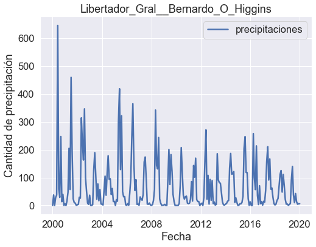

```python
grafprec(region='Libertador_Gral__Bernardo_O_Higgins',fechamin='2000-01-01',fechamax='2020-01-01')
```

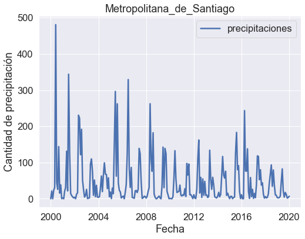

```python
grafprec(region='Metropolitana_de_Santiago',fechamin='2000-01-01',fechamax='2020-01-01')
```

Lamentablemente la tendencia se observa a la baja en los últimos 20 años respecto a la cantidad de precipitación caida. Los patrones estacionales por el otro lado, siguen manteniendose debido a las estaciones a lo largo del tiempo.

```python
anios=['1982', '1992', '2002', '2012', '2019']
```

```python
for i in anios:
    print(int(i))
```

```
1982
1992
2002
2012
2019
```

```python
def grafmes(anios,region):
    plt.rcParams["figure.figsize"] = (18, 12)
    j=1
    for i in anios:
        auxdf=precip[(precip['date'].dt.year==int(i))]
        plt.subplot(2,3, j)
        sns.lineplot(x='date', y=region, data=auxdf,label=i, markers=True);
        plt.xticks(rotation=30)
        plt.xlabel("")
        j=j+1
```

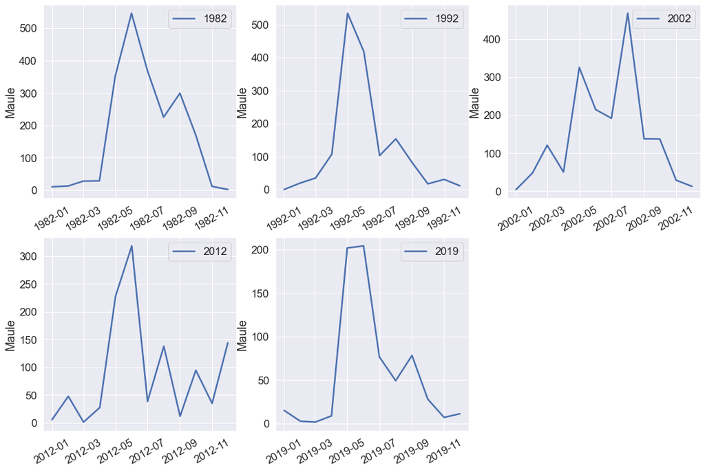

```python
grafmes(anios=['1982', '1992', '2002', '2012', '2019'],region='Maule')
```

```python
np.max(banco.Periodo)
```

```
Timestamp('2020-11-01 00:00:00')
```

```python
def grafprec(df = banco, serie1="PIB_Agropecuario_silvicola", serie2 = "PIB_Servicios_financieros",fechamin='2013-01-01',fechamax= '2020-04-01'):
    '''
    Esta funcion recibe el DF, region (columna dentro del df) y rango de fechas (se asume que el df tiene fechas)
    Tiene corrección de errores para fechas o regiones mal ingresadas
    '''
    plt.rcParams["figure.figsize"] = (16, 6)
    if ((df.columns.str.contains(serie1).any()) | (df.columns.str.contains(serie2).any())):
        if (df['Periodo'].astype(str).str.contains(fechamin).any())&(df['Periodo'].astype(str).str.contains(fechamax).any()):
            df1 =  df.loc[:,['Periodo', serie1]][df.loc[:,['Periodo', serie1]][serie1].notna()]
            df2 =  df.loc[:,['Periodo', serie2]][df.loc[:,['Periodo', serie2]][serie2].notna()]
            # Se remueven caracteres no numericos de las series:
            df1 = df1[df1[serie1].str.replace('.','').str.isnumeric()]
            df2 = df2[df2[serie2].str.replace('.','').str.isnumeric()]
            # Se transforman a numeros para graficar
            df1[serie1] = df1[serie1].str.replace('.','').astype(float)
            df2[serie2] = df2[serie2].str.replace('.','').astype(float)


            plt.subplot(1,2,1)
            sns.lineplot(x='Periodo', y=serie1, data=df1);
            plt.xticks(rotation=30)
            plt.ylabel("")
            plt.title(serie1)
            plt.ticklabel_format(style='plain', axis='y')
            plt.subplot(1,2,2)
            sns.lineplot(x='Periodo', y=serie2, data=df2, markers=True);
            plt.xticks(rotation=30)
            plt.ylabel("")
            plt.title(serie2)
            plt.ticklabel_format(style='plain', axis='y')
            plt.subplots_adjust(wspace = 0.35)
        else:
            print("Una de las fechas es incorrecta")
    else:
        print("Una de las columnas no está en la base del banco")
    return
```

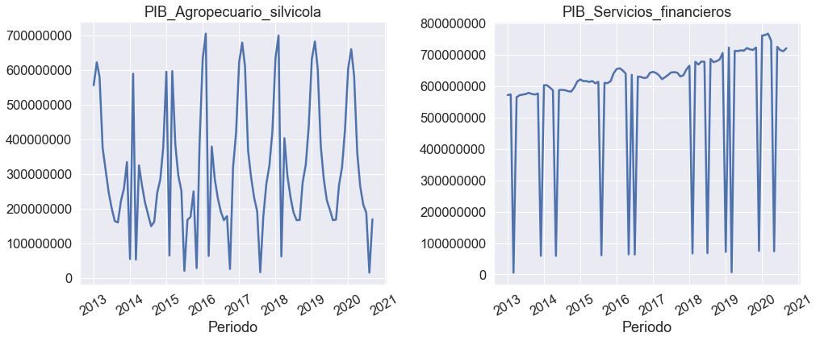

```python
grafprec(serie1="PIB_Agropecuario_silvicola", serie2 = "PIB_Servicios_financieros",fechamin='2013-01-01',fechamax= '2020-11-01')
```

Se puede observar que Agropecuario pareciera no tener una tendencia que varíe en el tiempo, a diferencia de servicios financieros que claramente va aumentando en el tiempo.

Ambas series parecen presentar una estacionalidad marcada por periodos anuales o bianuales.

Lo otro que se observa es la diferencia abismante entre valores desde 0 a cerca de 600M por ejemplo en servicios financieros. Esto simplemente reafirma lo que anteriormente se expuso referente a la alteración de los datos.

# 4.- Tratamiento y creación de variables

Dado los tratamientos anteriores, ya es posible hacer los join necesarios pues todas las fechas de los 3 set de datos tienen el mismo formato y pueden ser usados como llave

```python
precip.loc[0,:'date']
```

```
date    1979-01-01 00:00:00
Name: 0, dtype: object
```

```python
banco.loc[0,:'Periodo']
```

```
Periodo    2013-03-01 00:00:00
Name: 0, dtype: object
```

```python
leche.loc[0,:'fecha']
```

```
Precio_leche                   3.85
fecha           1979-01-01 00:00:00
Name: 0, dtype: object
```

```python
gran_df = leche.merge(precip, left_on='fecha', right_on='date',how='left').merge(banco,left_on='fecha',right_on="Periodo",how='left')
```

```python
gran_df.head(1)
```

|  | Precio_leche | fecha | date | Coquimbo | Valparaiso | Metropolitana_de_Santiago | Libertador_Gral__Bernardo_O_Higgins | Maule | Biobio | La_Araucania | ... | Indice_de_tipo_de_cambio_real___TCR_promedio_1986_100 | Indice_de_produccion_industrial | Indice_de_produccion_industrial__mineria | Indice_de_produccion_industrial_electricidad__gas_y_agua | Indice_de_produccion_industrial__manufacturera | Generacion_de_energia_electrica_CDEC_GWh | Indice_de_ventas_comercio_real_IVCM | Indice_de_ventas_comercio_real_no_durables_IVCM | Indice_de_ventas_comercio_real_durables_IVCM | Ventas_autos_nuevos |
| --- | --- | --- | --- | --- | --- | --- | --- | --- | --- | --- | --- | --- | --- | --- | --- | --- | --- | --- | --- | --- | --- |
| 0 | 3.85 | 1979-01-01 | 1979-01-01 | 2.641948 | 0.587062 | 2.447114 | 1.608992 | 3.736215 | 17.859634 | 25.21294 | ... | NaN | NaN | NaN | NaN | NaN | NaN | NaN | NaN | NaN | NaN |

1 rows × 96 columns

Variables Anio, mes y trimestre

```python
pd.DatetimeIndex(gran_df['fecha']).year
```

```
Int64Index([1979, 1979, 1979, 1979, 1979, 1979, 1979, 1979, 1979, 1979,
            ...
            2020, 2020, 2020, 2020, 2020, 2020, 2020, 2020, 2021, 2021],
           dtype='int64', name='fecha', length=508)
```

```python
gran_df['Anio']= pd.DatetimeIndex(gran_df['fecha']).year
gran_df['Mes']= pd.DatetimeIndex(gran_df['fecha']).month
gran_df['Trimestre']=np.where(gran_df['Mes']<=3,'Primer Trimestre',np.where(gran_df['Mes']<=6,'Segundo Trimestre',np.where(gran_df['Mes']<=9,'Tercer Trimestre', 'Cuarto Trimestre')))
```

# 5.- Modelo

Idealmente las variables explicativas no deben estar correlacionadas entre si para evitar multicolinealidad. Desafortunadamente por tiempo, no me es posible realizar el análisis bivariado necesario para esto. Por lo que procederé a realizar un modelo ARIMA con el set de Precipitaciones.

Primero realizaré un modelo sin el set de datos del banco, que parece estar demasiado alterado. Se utiliza la metodología de ICHI.PRO: https://ichi.pro/es/prediccion-de-series-temporales-usando-sarimax-182932574932054

```python
import pandas as pd
import numpy as np
import matplotlib.pyplot as plt
import seaborn as sns
from pandas.plotting import register_matplotlib_converters
register_matplotlib_converters()
%matplotlib inline
```

```python
data = gran_df.iloc[:,[0,1,3,4,5,6,7,8,9,10]]
```

```python
steps=-1
dataset_for_prediction= data.copy()
dataset_for_prediction['Actual']=dataset_for_prediction['Precio_leche'].shift(steps)
dataset_for_prediction.head(3)
```

|  | Precio_leche | fecha | Coquimbo | Valparaiso | Metropolitana_de_Santiago | Libertador_Gral__Bernardo_O_Higgins | Maule | Biobio | La_Araucania | Los_Rios | Actual |
| --- | --- | --- | --- | --- | --- | --- | --- | --- | --- | --- | --- |
| 0 | 3.85 | 1979-01-01 | 2.641948 | 0.587062 | 2.447114 | 1.608992 | 3.736215 | 17.859634 | 25.212940 | 45.596447 | 4.58 |
| 1 | 4.58 | 1979-02-01 | 1.179804 | 2.432192 | 3.997852 | 4.346310 | 16.347637 | 17.680612 | 18.085072 | 34.075039 | 5.18 |
| 2 | 5.18 | 1979-03-01 | 0.255490 | 0.020601 | 0.000000 | 0.055488 | 0.545324 | 14.435698 | 28.696504 | 66.232248 | 6.06 |

```python
dataset_for_prediction=dataset_for_prediction.dropna()
```

```python
dataset_for_prediction['Date'] =pd.to_datetime(dataset_for_prediction['fecha'])
dataset_for_prediction.index= dataset_for_prediction['Date']
```

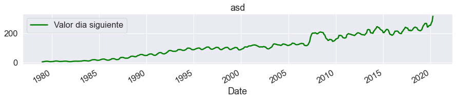

```python
dataset_for_prediction['Precio_leche'].plot(color='green', figsize=(15,2))
plt.legend(['Valor dia siguiente','Precio_leche'])
plt.title('asd')
```

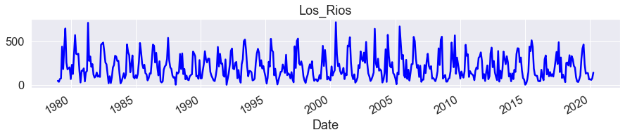

```python
dataset_for_prediction['Los_Rios'].plot(color='blue', figsize=(15,2))
plt.title('Los_Rios')
```

Escalar las características de entrada: regiones para set exógeno y precio leche desfasado para variable respuesta

```python
from sklearn.preprocessing import MinMaxScaler
sc_in = MinMaxScaler(feature_range=(0, 1))
scaled_input = sc_in.fit_transform(dataset_for_prediction[['Coquimbo','Valparaiso','Metropolitana_de_Santiago','Libertador_Gral__Bernardo_O_Higgins','Maule','Biobio','La_Araucania','Los_Rios','Precio_leche']])
scaled_input =pd.DataFrame(scaled_input)
X= scaled_input
```

```python
dataset_for_prediction
```

| Date | Precio_leche | fecha | Coquimbo | Valparaiso | Metropolitana_de_Santiago | Libertador_Gral__Bernardo_O_Higgins | Maule | Biobio | La_Araucania | Los_Rios | Actual | Date |
| --- | --- | --- | --- | --- | --- | --- | --- | --- | --- | --- | --- | --- |
| 1979-01-01 | 3.85 | 1979-01-01 | 2.641948 | 0.587062 | 2.447114 | 1.608992 | 3.736215 | 17.859634 | 25.212940 | 45.596447 | 4.58 | 1979-01-01 |
| 1979-02-01 | 4.58 | 1979-02-01 | 1.179804 | 2.432192 | 3.997852 | 4.346310 | 16.347637 | 17.680612 | 18.085072 | 34.075039 | 5.18 | 1979-02-01 |
| 1979-03-01 | 5.18 | 1979-03-01 | 0.255490 | 0.020601 | 0.000000 | 0.055488 | 0.545324 | 14.435698 | 28.696504 | 66.232248 | 6.06 | 1979-03-01 |
| 1979-04-01 | 6.06 | 1979-04-01 | 10.173699 | 11.745779 | 13.722349 | 12.989194 | 21.880607 | 39.136483 | 43.617921 | 73.548127 | 7.25 | 1979-04-01 |
| 1979-05-01 | 7.25 | 1979-05-01 | 1.039098 | 18.609286 | 50.187148 | 104.451550 | 143.914334 | 219.729235 | 279.409718 | 438.005116 | 7.71 | 1979-05-01 |
| ... | ... | ... | ... | ... | ... | ... | ... | ... | ... | ... | ... | ... |
| 2019-12-01 | 253.86 | 2019-12-01 | 0.287895 | 0.165390 | 3.601443 | 6.198806 | 11.327313 | 14.014122 | 27.321858 | 62.170090 | 254.10 | 2019-12-01 |
| 2020-01-01 | 254.10 | 2020-01-01 | 3.299797 | 2.003685 | 6.937148 | 6.154279 | 7.875591 | 19.518225 | 35.916618 | 63.389625 | 270.15 | 2020-01-01 |
| 2020-02-01 | 270.15 | 2020-02-01 | 0.179216 | 0.003701 | 0.032064 | 0.017628 | 0.200483 | 10.108504 | 29.001988 | 55.838889 | 279.88 | 2020-02-01 |
| 2020-03-01 | 279.88 | 2020-03-01 | 0.003451 | 0.000666 | 0.000000 | 0.000000 | 0.115566 | 12.462699 | 28.310937 | 73.640866 | 316.25 | 2020-03-01 |
| 2020-04-01 | 316.25 | 2020-04-01 | 0.556085 | 4.664708 | 16.033775 | 19.795752 | 37.348511 | 66.764275 | 73.813290 | 140.076757 | 318.88 | 2020-04-01 |

498 rows × 12 columns

```python
sc_out = MinMaxScaler(feature_range=(0, 1))
scaler_output = sc_out.fit_transform(dataset_for_prediction[['Actual']])
scaler_output =pd.DataFrame(scaler_output)
y=scaler_output
```

```python
X.rename(columns={0:'Coquimbo', 1:'Valparaiso', 2:'Metropolitana_de_Santiago', 3:'Libertador_Gral__Bernardo_O_Higgins', 4:'Maule', 5:'Biobio', 6:'La_Araucania', 7:'Los_Rios',8:'Precio_leche'}, inplace=True)
X.tail(2)
```

|  | Coquimbo | Valparaiso | Metropolitana_de_Santiago | Libertador_Gral__Bernardo_O_Higgins | Maule | Biobio | La_Araucania | Los_Rios | Precio_leche |
| --- | --- | --- | --- | --- | --- | --- | --- | --- | --- |
| 496 | 0.000010 | 0.000002 | 0.000000 | 0.000000 | 0.000152 | 0.017741 | 0.042809 | 0.101665 | 0.883579 |
| 497 | 0.001602 | 0.010576 | 0.030564 | 0.030667 | 0.049196 | 0.095045 | 0.111626 | 0.194325 | 1.000000 |

```python
y.rename(columns={0:'Precio_Leche_mes_siguiente'}, inplace= True)
y.index=dataset_for_prediction.index
y.head(2)
```

| Date | Precio_Leche_mes_siguiente |
| --- | --- |
| 1979-01-01 | 0.000000 |
| 1979-02-01 | 0.001909 |

```python
X.index = dataset_for_prediction.index
```

```python
train_size=int(len(data) *0.8)
test_size = int(len(data)) - train_size
train_X, train_y = X[:train_size].dropna(), y[:train_size].dropna()
test_X, test_y = X[train_size:].dropna(), y[train_size:].dropna()
```

Descomposición de series temporales en varios componentes: tendencia, estacionalidad y ruido aleatorio

*Modelo aditivo = Tendencia + Estacionalidad + Ruido aleatorio*

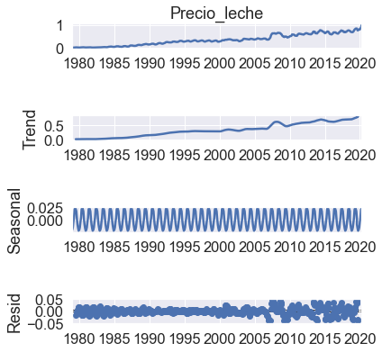

```python
import statsmodels.api as sm
seas_d=sm.tsa.seasonal_decompose(X['Precio_leche'],model='add',freq=12);
fig=seas_d.plot()
fig.set_figheight(6)
plt.show()
```

Se observa en el 3er grafico la estacionalidad constante en el tiempo, lo cual cumplirá el primer supuesto del modelo: la media y la varianza seguirán siendo las mismas en el futuro.

A continuación se buscarán los mejores parámetros del modelo y su diferenciación necesaria mediante un proceso auto_arima.

Observación: el hiperparámetro "exogenous" utilizará el set de datos de precipitaciones como regresores

```python
#!pip install pmdarima
```

```python
from pmdarima.arima import auto_arima
step_wise=auto_arima(train_y,
 exogenous= train_X,
 start_p=1, start_q=1,
 max_p=7, max_q=7,
 d=1, max_d=7,
 trace=True,
 error_action='ignore',
 suppress_warnings=True,
 stepwise=True)
```

```
Performing stepwise search to minimize aic
 ARIMA(1,1,1)(0,0,0)[0] intercept   : AIC=-2626.316, Time=1.20 sec
 ARIMA(0,1,0)(0,0,0)[0] intercept   : AIC=-2630.286, Time=0.38 sec
 ARIMA(1,1,0)(0,0,0)[0] intercept   : AIC=-2628.654, Time=0.19 sec
 ARIMA(0,1,1)(0,0,0)[0] intercept   : AIC=-2628.675, Time=1.02 sec
 ARIMA(0,1,0)(0,0,0)[0]             : AIC=-2630.704, Time=0.38 sec

Best model:  ARIMA(0,1,0)(0,0,0)[0]
Total fit time: 3.199 seconds
```

```python
step_wise.summary()
```

SARIMAX Results

| Dep. Variable: | y | No. Observations: | 406 |
| --- | --- | --- | --- |
| Model: | SARIMAX(0, 1, 0) | Log Likelihood | 1325.352 |
| Date: | Sun, 18 Apr 2021 | AIC | -2630.704 |
| Time: | 15:14:04 | BIC | -2590.665 |
| Sample: | 01-01-1979 | HQIC | -2614.856 |
|  | - 10-01-2012 |  |  |
| Covariance Type: | opg |  |  |

|  | coef | std err | z | P>\|z\| | [0.025 | 0.975] |
| --- | --- | --- | --- | --- | --- | --- |
| Coquimbo | 0.0086 | 0.013 | 0.661 | 0.509 | -0.017 | 0.034 |
| Valparaiso | -0.0188 | 0.021 | -0.909 | 0.364 | -0.059 | 0.022 |
| Metropolitana_de_Santiago | 0.0162 | 0.024 | 0.677 | 0.498 | -0.031 | 0.063 |
| Libertador_Gral__Bernardo_O_Higgins | 0.0037 | 0.031 | 0.119 | 0.906 | -0.057 | 0.064 |
| Maule | -0.0098 | 0.026 | -0.372 | 0.710 | -0.061 | 0.042 |
| Biobio | 0.0049 | 0.023 | 0.211 | 0.833 | -0.041 | 0.051 |
| La_Araucania | -0.0097 | 0.023 | -0.423 | 0.672 | -0.055 | 0.035 |
| Los_Rios | 0.0083 | 0.013 | 0.621 | 0.535 | -0.018 | 0.034 |
| Precio_leche | 0.5972 | 0.031 | 19.379 | 0.000 | 0.537 | 0.658 |
| sigma2 | 8.409e-05 | 2.68e-06 | 31.336 | 0.000 | 7.88e-05 | 8.93e-05 |

| Ljung-Box (Q): | 365.42 | Jarque-Bera (JB): | 2589.24 |
| --- | --- | --- | --- |
| Prob(Q): | 0.00 | Prob(JB): | 0.00 |
| Heteroskedasticity (H): | 11.46 | Skew: | 1.04 |
| Prob(H) (two-sided): | 0.00 | Kurtosis: | 15.21 |

Warnings:  
[1] Covariance matrix calculated using the outer product of gradients (complex-step).

Entrenamiento del modelo

```python
from statsmodels.tsa.statespace.sarimax import SARIMAX
model= SARIMAX(train_y,
 exog=train_X,
 order=(0,1,0),
 enforce_invertibility=False, enforce_stationarity=False)
```

```python
results= model.fit()
```

```python
predictions= results.predict(start =406, end=497,exog=test_X)
```

```python
forecast_1= results.forecast(steps=92, exog=test_X)
```

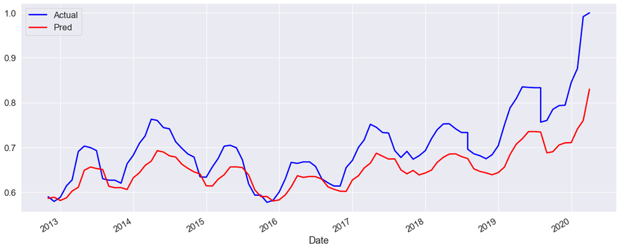

```python
act= pd.DataFrame(scaler_output.iloc[train_size:, 0])
predictions=pd.DataFrame(predictions)
predictions.reset_index(drop=True, inplace=True)
predictions.index=test_X.index
predictions['Actual'] = act['Precio_Leche_mes_siguiente']
predictions.rename(columns={0:'Pred'}, inplace=True)
predictions['Actual'].plot(figsize=(20,8), legend=True, color='blue')
predictions['Pred'].plot(legend=True, color='red', figsize=(20,8))
```

Desafortunadamente los datos de precipitación no son suficientes para generar una predicción totalmente fiela lo esperado, pero da unos valores similares a los actuales

```python
results.forecast(steps=92, exog=test_X)
```

```
2012-11-01    0.586068
2012-12-01    0.588659
2013-01-01    0.581268
2013-02-01    0.587307
2013-03-01    0.602333
                ...
2020-02-01    0.709924
2020-03-01    0.710452
2020-04-01    0.740940
2020-05-01    0.759767
2020-06-01    0.829708
Freq: MS, Length: 92, dtype: float64
```

```python
forecast_apple= pd.DataFrame(forecast_1)
forecast_apple.reset_index(drop=True, inplace=True)
forecast_apple.index=test_X.index
forecast_apple['Actual'] =scaler_output.iloc[train_size:, 0]
forecast_apple.rename(columns={0:'Forecast'}, inplace=True)
```

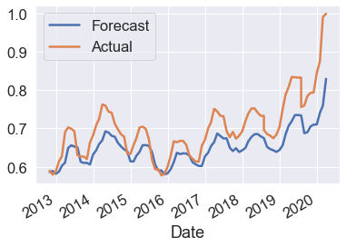

```python
forecast_apple['Forecast'].plot(legend=True)
forecast_apple['Actual'].plot(legend=True)
```

```python
from statsmodels.tools.eval_measures import rmse
error=rmse(predictions['Pred'], predictions['Actual'])
error
```

```
0.06380795768048506
```

```python
trainPredict = sc_out.inverse_transform(predictions[['Pred']])
testPredict = sc_out.inverse_transform(predictions[['Actual']])
```

Solo se ha predicho con los valores existentes de la variable exogena precip, que en este caso llegan hasta la fecha 2020-04-01. Para solucionar esto lo que haría es realizar series temporales individuales (Como se presenta en el proyecto AutoArima_R), para cada una de las precipitaciones, para así extender las variables exógenas hasta el 2021-03 que es el precio que se desea predecir.

Desafortunadamente no tengo más tiempo para el desarrollo del proyecto. Se demuestra la proyección auto.arima independiente sin variables exogenas en el proyecto de R para demostrar manejo de ambos softwares.